# Case Study 8 & 9

```r
#Bring in Libraries
#install.packages('plyr')
#install.packages('tidyr')
#install.packages('dplyr')
#install.packages('tidyverse')
#install.packages('class')
#install.packages('caret')
#install.packages('e1071')
library(class)
library(caret)
```

```r
library(e1071)
library(ggplot2)
library(plyr)
library(tidyr)
library(dplyr)
```

## R Markdown

Bring in Data

```r
#Pulled in the two csv documents
#Read.csv is the function i used to pull the documents
Beers_df=read.csv("/Users/muchigi.kimari@mckesson.com/Desktop/Doing_Data_Science/Doing_Data_Science/Doing_datascience/CodeBook/Beers.csv",header=TRUE)
Breweries_df=read.csv("/Users/muchigi.kimari@mckesson.com/Desktop/Doing_Data_Science/Doing_Data_Science/Doing_datascience/CodeBook/Breweries.csv",header=TRUE)
```

Question 1: How many breweries are present in each state?

```r
#Created a dataframe  called Breweries_state to show the breweries in each State
Breweries_State <-aggregate(cbind(count = Name) ~ State,data = Breweries_df,FUN=function(x){NROW(x)})

#showed the top two rows
head(Breweries_df,2)
```

```
##   Brew_ID                      Name        City State
## 1       1        NorthGate Brewing  Minneapolis    MN
## 2       2 Against the Grain Brewery  Louisville    KY
```

Divided the dataframe into two, so that we could fit all the states into one bar graph

```r
# divided two dataframes into two

Breweries_df1<- head(Breweries_State,26)
Breweries_df2<-tail(Breweries_State,25)
```

The below shows a bar graph for the first half of the data

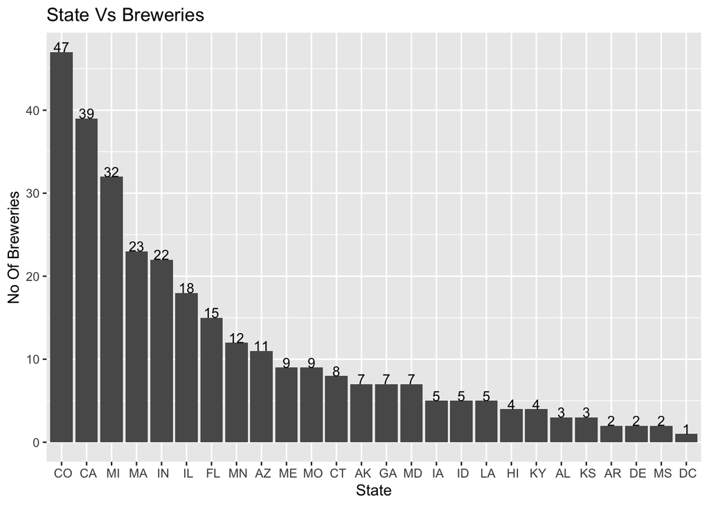

```r
ggplot(Breweries_df1, aes(x=reorder(State,-count), y=count))+geom_bar(stat = 'identity')+geom_text(aes(label=count),vjust=0, size=3.5)+ggtitle("State Vs Breweries")+xlab("State") + ylab("No Of Breweries")
```

The below shows a bar graph for the second half of the data

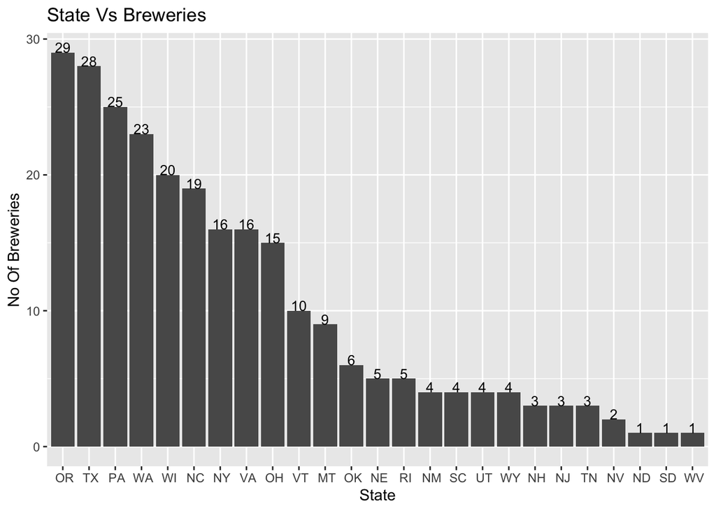

```r
ggplot(Breweries_df2, aes(x=reorder(State,-count), y=count))+geom_bar(stat = 'identity')+geom_text(aes(label=count),vjust=0, size=3.5)+ggtitle("State Vs Breweries")+xlab("State") + ylab("No Of Breweries")
```

Question 2 Merge beer data with the breweries data. Print the first 6 observations and the last six observations to check the merged file. (RMD only, this does not need to be included in the presentation or the deck.)

[output not shown]

Question 3: Address the missing values in each column.

```r
#Changed all the null values to NA
CombinedData[CombinedData=='']<-NA

#Count all the NA's
colSums(is.na(CombinedData))
```

```
##      Brewery_id            Name         Beer_ID             ABV
##               0               0               0              62
##             IBU           Style          Ounces Brewery_id.Name
##            1005               5               0               0
##            City           State
##               0               0
```

Question 4: Compute the median alcohol content and international bitterness unit for each state. Plot a bar chart to compare.

```r
#changed #NA to 0 to get actual medians
CombinedData[is.na(CombinedData)]<-0
#created the dataframes with medians for each State
Medians<-CombinedData%>%group_by(State)%>%summarise(median.ABV=median(ABV),median.IBU=median(IBU))

#top 3 data
head(Medians,3)
```

```
## # A tibble: 3 x 3
##   State median.ABV median.IBU
##   <fct>      <dbl>      <dbl>
## 1 " AK"      0.056       17
## 2 " AL"      0.06        39.5
## 3 " AR"      0.052        0
```

Divided the dataframes into two again to fit all the states in the bar graph

```r
# divided two dataframes into two

Medians_df1<- head(Medians,26)
medians_df2<-tail(Medians,25)
```

The below shows a bar graph for ABV for the first half of the data

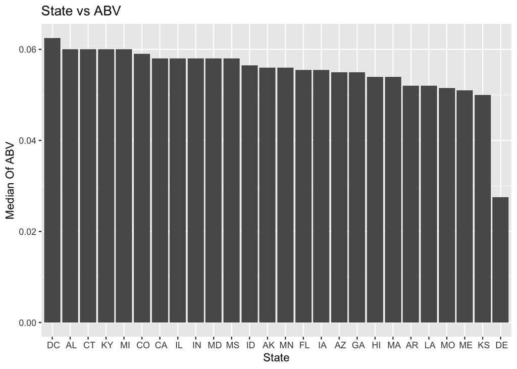

```r
ggplot(Medians_df1,aes(x=reorder(State,-median.ABV),y=median.ABV))+geom_bar(stat ='identity')+ggtitle("State vs ABV")+xlab("State")+ylab("Median Of ABV")
```

The below shows a bar graph for ABV for the Second half of the data

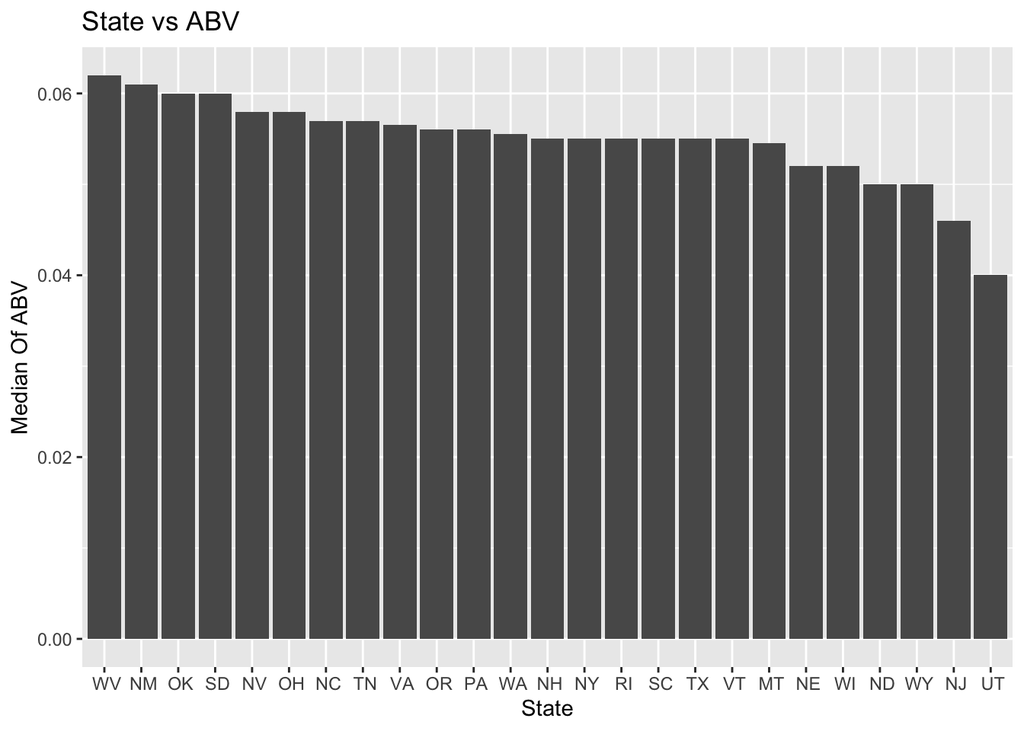

```r
ggplot(medians_df2,aes(x=reorder(State,-median.ABV),y=median.ABV))+geom_bar(stat ='identity')+ggtitle("State vs ABV")+xlab("State")+ylab("Median Of ABV")
```

The below shows a bar graph for IBU for the first half of the data

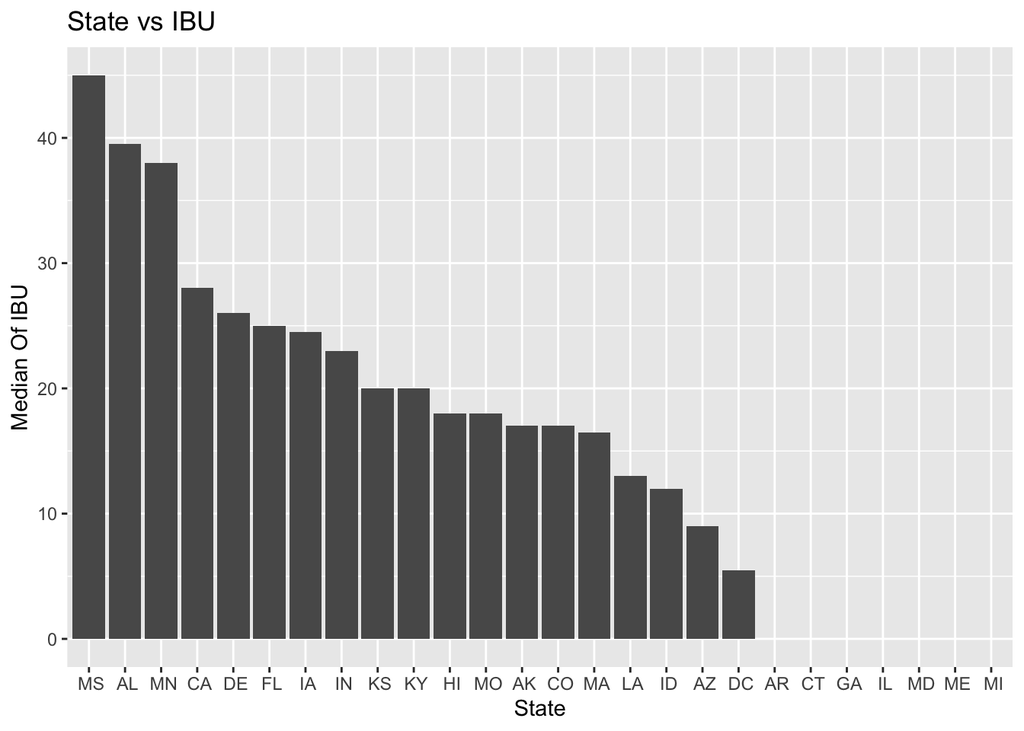

```r
ggplot(Medians_df1,aes(x=reorder(State,-median.IBU),y=median.IBU))+geom_bar(stat ='identity')+ggtitle("State vs IBU")+xlab("State")+ylab("Median Of IBU")
```

The below shows a bar graph for IBV for the Second half of the data

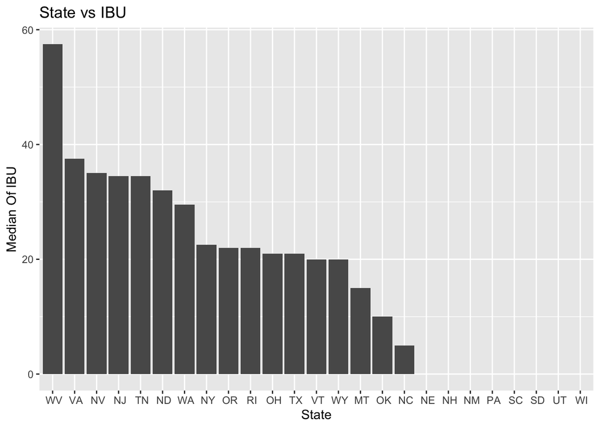

```r
ggplot(medians_df2,aes(x=reorder(State,-median.IBU),y=median.IBU))+geom_bar(stat ='identity')+ggtitle("State vs IBU")+xlab("State")+ylab("Median Of IBU")
```

Question 5: Which state has the maximum alcoholic (ABV) beer? Which state has the most bitter (IBU) beer?

the state with the highest ABV = Colorado the state with the highest IBU = Oregon

```r
Maximum<-CombinedData%>%group_by(State)%>%summarise(Max.ABV=max(ABV),Max.IBU=max(IBU))

head(Maximum,5)
```

```
## # A tibble: 5 x 3
##   State Max.ABV Max.IBU
##   <fct>   <dbl>   <dbl>
## 1 " AK"   0.068      71
## 2 " AL"   0.093     103
## 3 " AR"   0.061      39
## 4 " AZ"   0.095      99
## 5 " CA"   0.099     115
```

Question 6: Comment on the summary statistics and distribution of the ABV variable.

```r
CombinedData[CombinedData==0]<-NA

summary(CombinedData$ABV)
```

```
##    Min. 1st Qu.  Median    Mean 3rd Qu.    Max.    NA's
## 0.00100 0.05000 0.05600 0.05977 0.06700 0.12800      62
```

Below is the histogram

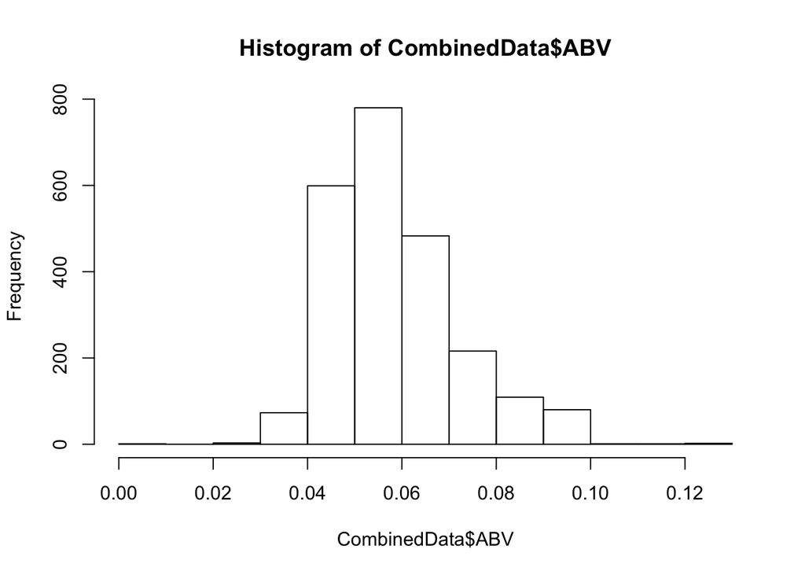

```r
hist(CombinedData$ABV)
```

Below is the qqnorm

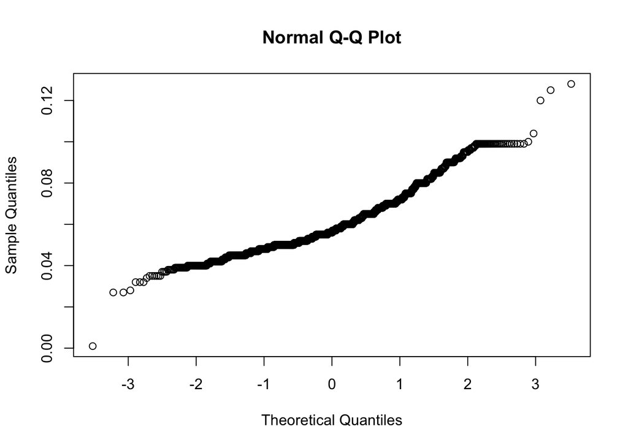

```r
qqnorm(CombinedData$ABV)
```

Question 7: Is there an apparent relationship between the bitterness of the beer and its alcoholic content? Draw a scatt10er plot. Make your best judgment of a relationship and EXPLAIN your answer.

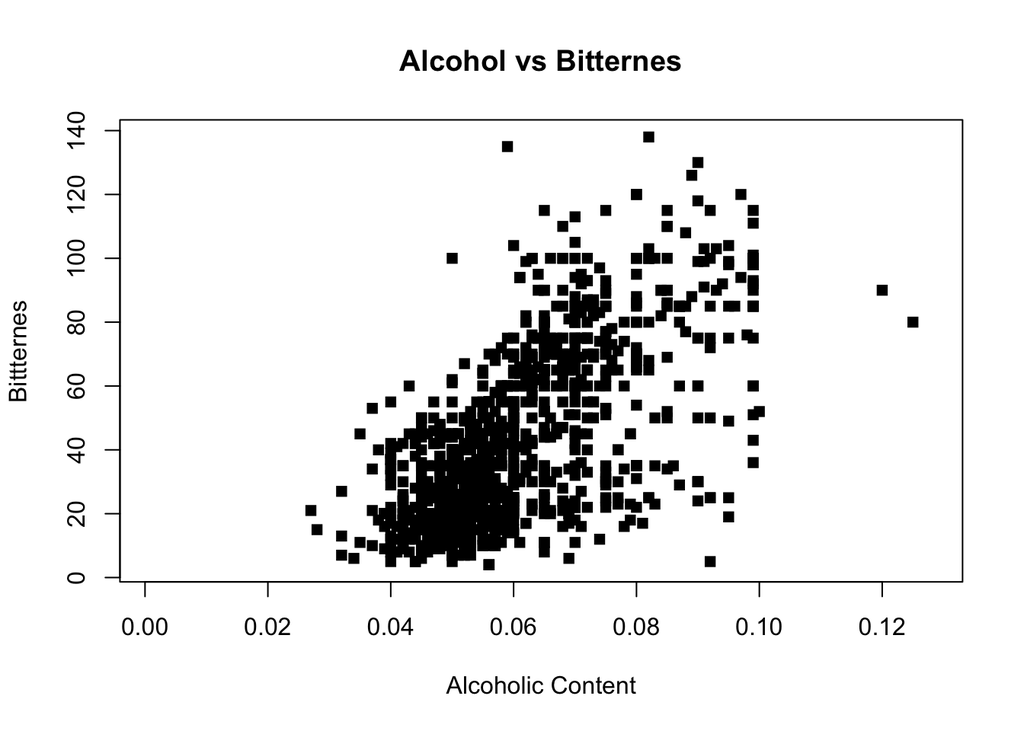

```r
plot(CombinedData$ABV,CombinedData$IBU,pch = 15,xlab = "Alcoholic Content",ylab = "Bittternes", main = "Alcohol vs Bitternes")
```

8. Budweiser would also like to investigate the difference with respect to IBU and ABV between IPAs (India Pale Ales) and other types of Ale (any beer with “Ale” in its name other than IPA). You decide to use KNN classification to investigate this relationship. Provide statistical evidence one way or the other. You can of course assume your audience is comfortable with percentages … KNN is very easy to understand conceptually.

In addition, while you have decided to use KNN to investigate this relationship (KNN is required) you may also feel free to supplement your response to this question with any other methods or techniques you have learned. Creativity and alternative solutions are always encouraged

```r
#first create the IPA and ALe Lables

CombinedData$Label <- ifelse(grepl("IPA",CombinedData$Style, ignore.case=T),"IPA",ifelse(grepl("Ale",CombinedData$Style,ignore.case = T),"Ale","other"))


# filter data to IPA NA ALe

Model_Table <- CombinedData%>% filter(Label=="IPA"|Label=="Ale")

Model_Table<-Model_Table%>%drop_na()
```

IPA has stronger Alcohol Content

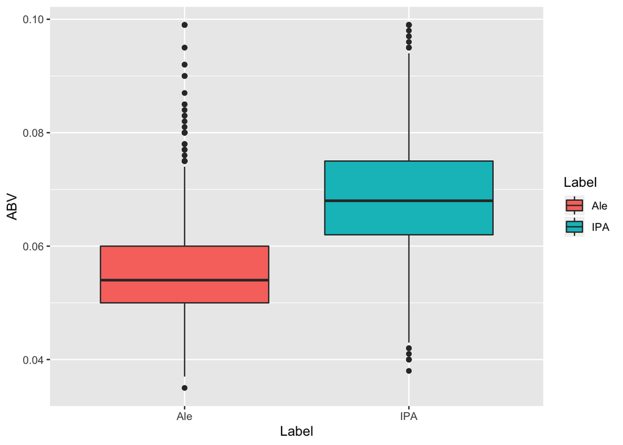

```r
Model_Table%>%ggplot(aes(x=Label,y=ABV,fill=Label))+geom_boxplot()
```

IPA’s has a higher Bitter content

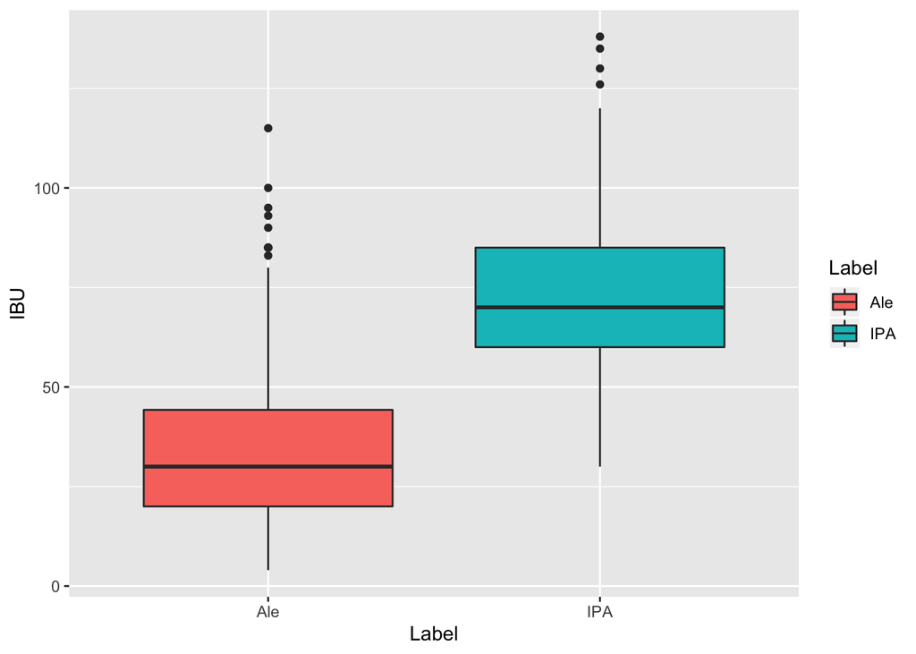

```r
Model_Table%>%ggplot(aes(x=Label,y=IBU,fill=Label))+geom_boxplot()
```

KNN model

```r
# create model


splitperc= .75
trainIndices = sample(1:dim(Model_Table)[1],round(splitperc*dim(Model_Table)[1]))
train = Model_Table[trainIndices,]
test = Model_Table[-trainIndices,]


# ran the model when k = 3

classifications = knn(train[,c(4,5)],test[,c(4,5)],train$Label, prob = TRUE, k = 3)
table(classifications,test$Label)
```

```
##
## classifications Ale IPA
##             Ale 116  16
##             IPA  20  89
```

```r
confusionMatrix(table(classifications,test$Label))
```

```
## Confusion Matrix and Statistics
##
##
## classifications Ale IPA
##             Ale 116  16
##             IPA  20  89
##
##                Accuracy : 0.8506
##                  95% CI : (0.7992, 0.8931)
##     No Information Rate : 0.5643
##     P-Value [Acc > NIR] : <2e-16
##
##                   Kappa : 0.6975
##
##  Mcnemar's Test P-Value : 0.6171
##
##             Sensitivity : 0.8529
##             Specificity : 0.8476
##          Pos Pred Value : 0.8788
##          Neg Pred Value : 0.8165
##              Prevalence : 0.5643
##          Detection Rate : 0.4813
##    Detection Prevalence : 0.5477
##       Balanced Accuracy : 0.8503
##
##        'Positive' Class : Ale
##
```

```r
#k = 5

classifications = knn(train[,c(4,5)],test[,c(4,5)],train$Label, prob = TRUE, k =10)
table(classifications,test$Label)
```

```
##
## classifications Ale IPA
##             Ale 122  22
##             IPA  14  83
```

```r
confusionMatrix(table(classifications,test$Label))
```

```
## Confusion Matrix and Statistics
##
##
## classifications Ale IPA
##             Ale 122  22
##             IPA  14  83
##
##                Accuracy : 0.8506
##                  95% CI : (0.7992, 0.8931)
##     No Information Rate : 0.5643
##     P-Value [Acc > NIR] : <2e-16
##
##                   Kappa : 0.6936
##
##  Mcnemar's Test P-Value : 0.2433
##
##             Sensitivity : 0.8971
##             Specificity : 0.7905
##          Pos Pred Value : 0.8472
##          Neg Pred Value : 0.8557
##              Prevalence : 0.5643
##          Detection Rate : 0.5062
##    Detection Prevalence : 0.5975
##       Balanced Accuracy : 0.8438
##
##        'Positive' Class : Ale
##
```

We plotted a graph to show the best KNN

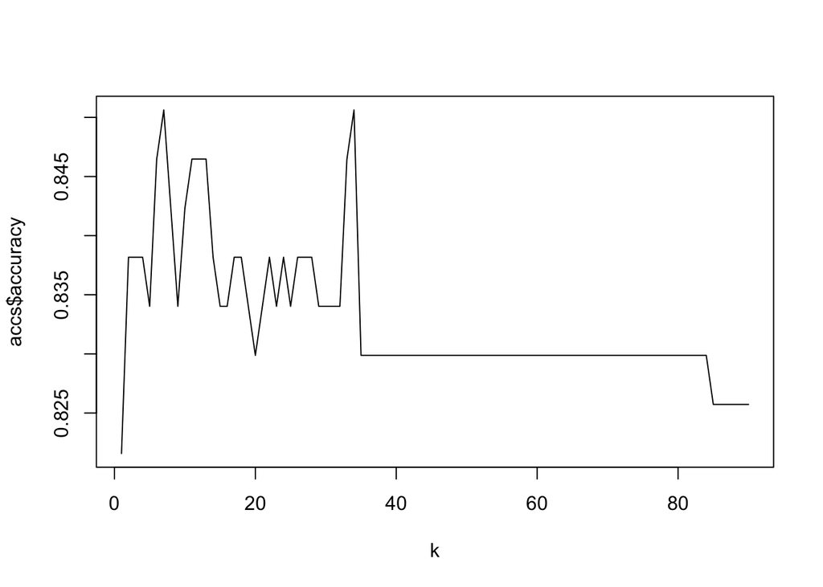

```r
accs = data.frame(accuracy = numeric(90), k = numeric(90))

for(i in 1:90)
{
  classifications = knn(train[,c(4,5)],test[,c(4,5)],train$Label, prob = TRUE, k = i)
  table(test$Label,classifications)
  CM = confusionMatrix(table(test$Label,classifications))
  accs$accuracy[i] = CM$overall[1]
  accs$k[i] = i
}
plot(accs$k,accs$accuracy, type = "l", xlab = "k")
```

9. Knock their socks off! Find one other useful inference from the data that you feel Budweiser may be able to find value in. You must convince them why it is important and back up your conviction with appropriate statistical evidence.

Since in Colardo has the most breweries in all the State, we will take a look at the average ABV AND IBU. and predict using KNN the perfect beer to sell in colorado

```r
#Filter the data to Colardo

Colorado <- CombinedData%>% filter(State==" CO")
```

Get Average ABU

```r
#Filter the data to Colardo

summary(Colorado$ABV)
```

```
##    Min. 1st Qu.  Median    Mean 3rd Qu.    Max.    NA's
## 0.04100 0.05200 0.06050 0.06337 0.07075 0.12800      15
```

Get Average IBU

```r
#Filter the data to Colardo
Colorado[is.na(Colorado)]<-0
summary(Colorado$IBU)
```

```
##    Min. 1st Qu.  Median    Mean 3rd Qu.    Max.
##    0.00    0.00   17.00   26.13   45.00  104.00
```

Predict - The best beer to sell is Ale in Co

```r
#Filter the data to Colardo
df = data.frame(ABV = 0.06337 , IBU= 26.13)
knn(Model_Table[,c(4,5)], df,Model_Table$Label, k = 3, prob = TRUE)
```

```
## [1] Ale
## attr(,"prob")
## [1] 1
## Levels: Ale IPA
```